# Data Visualisation project

Janani Krishnamurthy

2024-12-13

## Libraries

```r
library(dplyr)
```

```r
library(tidyr)
library(ggplot2)
library(reshape2)
library(treemapify)
library(ggmosaic)
library(RColorBrewer)
```

## Data Pre-processing

```r
data <- read.csv("user_behavior_dataset 1.csv")
head(data)
```

```
##   User.ID   Device.Model Operating.System App.Usage.Time..min.day.
## 1       1 Google Pixel 5          Android                      393
## 2       2      OnePlus 9          Android                      268
## 3       3   Xiaomi Mi 11          Android                      154
## 4       4 Google Pixel 5          Android                      239
## 5       5      iPhone 12              iOS                      187
## 6       6 Google Pixel 5          Android                       99
##   Screen.On.Time..hours.day. Battery.Drain..mAh.day. Number.of.Apps.Installed
## 1                        6.4                    1872                       67
## 2                        4.7                    1331                       42
## 3                        4.0                     761                       32
## 4                        4.8                    1676                       56
## 5                        4.3                    1367                       58
## 6                        2.0                     940                       35
##   Data.Usage..MB.day. Age Gender User.Behavior.Class
## 1                1122  40   Male                   4
## 2                 944  47 Female                   3
## 3                 322  42   Male                   2
## 4                 871  20   Male                   3
## 5                 988  31 Female                   3
## 6                 564  31   Male                   2
```

```r
# Remove duplicates
data <- data %>% distinct()
summary(data)
```

```
##     User.ID      Device.Model       Operating.System   App.Usage.Time..min.day.
##  Min.   :  1.0   Length:700         Length:700         Min.   : 30.0
##  1st Qu.:175.8   Class :character   Class :character   1st Qu.:113.2
##  Median :350.5   Mode  :character   Mode  :character   Median :227.5
##  Mean   :350.5                                         Mean   :271.1
##  3rd Qu.:525.2                                         3rd Qu.:434.2
##  Max.   :700.0                                         Max.   :598.0
##  Screen.On.Time..hours.day. Battery.Drain..mAh.day. Number.of.Apps.Installed
##  Min.   : 1.000             Min.   : 302.0          Min.   :10.00
##  1st Qu.: 2.500             1st Qu.: 722.2          1st Qu.:26.00
##  Median : 4.900             Median :1502.5          Median :49.00
##  Mean   : 5.273             Mean   :1525.2          Mean   :50.68
##  3rd Qu.: 7.400             3rd Qu.:2229.5          3rd Qu.:74.00
##  Max.   :12.000             Max.   :2993.0          Max.   :99.00
##  Data.Usage..MB.day.      Age           Gender          User.Behavior.Class
##  Min.   : 102.0      Min.   :18.00   Length:700         Min.   :1.00
##  1st Qu.: 373.0      1st Qu.:28.00   Class :character   1st Qu.:2.00
##  Median : 823.5      Median :38.00   Mode  :character   Median :3.00
##  Mean   : 929.7      Mean   :38.48                      Mean   :2.99
##  3rd Qu.:1341.0      3rd Qu.:49.00                      3rd Qu.:4.00
##  Max.   :2497.0      Max.   :59.00                      Max.   :5.00
```

```r
nrow(data)
```

```
## [1] 700
```

```r
# Standardize categorical data

# Convert `Operating System` and `Gender` columns to factor type
data$Operating.System <- as.factor(data$Operating.System)
data$Gender <- as.factor(data$Gender)

# Standardize case
data$Device.Model <- tolower(data$Device.Model)
data$Operating.System <- tolower(data$Operating.System)
data$Gender <- tolower(data$Gender)
```

```r
# Remove rows with unrealistic values
data <- data %>%
  filter(
    `App.Usage.Time..min.day.` >= 0 & `App.Usage.Time..min.day.` <= 1440,
    `Screen.On.Time..hours.day.` >= 0 & `Screen.On.Time..hours.day.` <= 24,
    `Battery.Drain..mAh.day.` >= 0
  )
```

```r
# Remove rows with missing values
data <- data %>%
  drop_na()
```

```r
# Convert Age and User Behavior Class to integer
data$Age <- as.integer(data$Age)
data$User.Behavior.Class <- as.integer(data$User.Behavior.Class)
```

```r
#Renaming the column names

data <- data %>%
  rename(
    User_ID = User.ID,
    Device_Model = Device.Model,
    Operating_System = Operating.System,
    App_Usage_Time_Mins_Per_Day = App.Usage.Time..min.day.,
    Screen_Time_Hours_Per_Day = Screen.On.Time..hours.day.,
    Battery_Consumption_mAh_Per_Day = Battery.Drain..mAh.day.,
    Number_Of_Apps_Installed = Number.of.Apps.Installed,
    Data_Usage_MB_Per_Day = Data.Usage..MB.day.,
    User_Behavior_Class = User.Behavior.Class
  )
```

```r
summary(data)
```

```
##     User_ID      Device_Model       Operating_System
##  Min.   :  1.0   Length:700         Length:700
##  1st Qu.:175.8   Class :character   Class :character
##  Median :350.5   Mode  :character   Mode  :character
##  Mean   :350.5
##  3rd Qu.:525.2
##  Max.   :700.0
##  App_Usage_Time_Mins_Per_Day Screen_Time_Hours_Per_Day
##  Min.   : 30.0               Min.   : 1.000
##  1st Qu.:113.2               1st Qu.: 2.500
##  Median :227.5               Median : 4.900
##  Mean   :271.1               Mean   : 5.273
##  3rd Qu.:434.2               3rd Qu.: 7.400
##  Max.   :598.0               Max.   :12.000
##  Battery_Consumption_mAh_Per_Day Number_Of_Apps_Installed Data_Usage_MB_Per_Day
##  Min.   : 302.0                  Min.   :10.00            Min.   : 102.0
##  1st Qu.: 722.2                  1st Qu.:26.00            1st Qu.: 373.0
##  Median :1502.5                  Median :49.00            Median : 823.5
##  Mean   :1525.2                  Mean   :50.68            Mean   : 929.7
##  3rd Qu.:2229.5                  3rd Qu.:74.00            3rd Qu.:1341.0
##  Max.   :2993.0                  Max.   :99.00            Max.   :2497.0
##       Age           Gender          User_Behavior_Class
##  Min.   :18.00   Length:700         Min.   :1.00
##  1st Qu.:28.00   Class :character   1st Qu.:2.00
##  Median :38.00   Mode  :character   Median :3.00
##  Mean   :38.48                      Mean   :2.99
##  3rd Qu.:49.00                      3rd Qu.:4.00
##  Max.   :59.00                      Max.   :5.00
```

```r
head(data)
```

```
##   User_ID   Device_Model Operating_System App_Usage_Time_Mins_Per_Day
## 1       1 google pixel 5          android                         393
## 2       2      oneplus 9          android                         268
## 3       3   xiaomi mi 11          android                         154
## 4       4 google pixel 5          android                         239
## 5       5      iphone 12              ios                         187
## 6       6 google pixel 5          android                          99
##   Screen_Time_Hours_Per_Day Battery_Consumption_mAh_Per_Day
## 1                       6.4                            1872
## 2                       4.7                            1331
## 3                       4.0                             761
## 4                       4.8                            1676
## 5                       4.3                            1367
## 6                       2.0                             940
##   Number_Of_Apps_Installed Data_Usage_MB_Per_Day Age Gender User_Behavior_Class
## 1                       67                  1122  40   male                   4
## 2                       42                   944  47 female                   3
## 3                       32                   322  42   male                   2
## 4                       56                   871  20   male                   3
## 5                       58                   988  31 female                   3
## 6                       35                   564  31   male                   2
```

```r
data <- data %>% mutate(Age_Group = cut(Age, breaks = seq(10, 70, by = 10), right = FALSE))
```

#### Heat Map

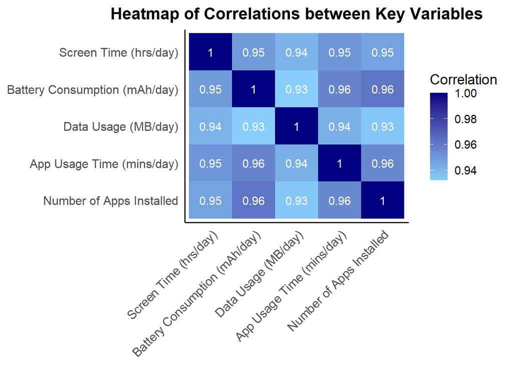

```r
library(reshape2)
num_vars <- data[, c("Screen_Time_Hours_Per_Day",
                     "Battery_Consumption_mAh_Per_Day",
                     "Data_Usage_MB_Per_Day",
                     "App_Usage_Time_Mins_Per_Day",
                     "Number_Of_Apps_Installed")]

# Create a simplified version of variable names
simplified_names <- c(
  "Screen Time (hrs/day)",
  "Battery Consumption (mAh/day)",
  "Data Usage (MB/day)",
  "App Usage Time (mins/day)",
  "Number of Apps Installed"
)

# Calculate correlation matrix
cor_matrix <- cor(num_vars, use = "complete.obs")

# Rename columns and rows in the correlation matrix
colnames(cor_matrix) <- simplified_names
rownames(cor_matrix) <- simplified_names

# Melt the correlation matrix for ggplot2
cor_melt <- melt(cor_matrix)

# Ensure both axes have the same factor levels
cor_melt$Var2 <- factor(cor_melt$Var2, levels = rev(colnames(cor_matrix)))

# Plot the heatmap
ggplot(cor_melt, aes(Var1, Var2, fill = value)) +
  geom_tile() +
  geom_text(aes(label = round(value, 2)), color = "white", size = 4) +
  scale_fill_gradient(low = "lightskyblue", high = "navy", name = "Correlation") +
  labs(
    title = "Heatmap of Correlations between Key Variables",
    x = NULL,
    y = NULL
  ) +
  theme_minimal(base_size = 14) +
  theme(
    plot.title = element_text(size = 16, face = "bold", hjust = 0.5),
    axis.text.x = element_text(angle = 45, hjust = 1, size = 12),
    axis.text.y = element_text(size = 12),
    panel.grid = element_blank(),
    panel.border = element_blank(),
    axis.line = element_line(color = "black")
  )
```

#### Screen On Time

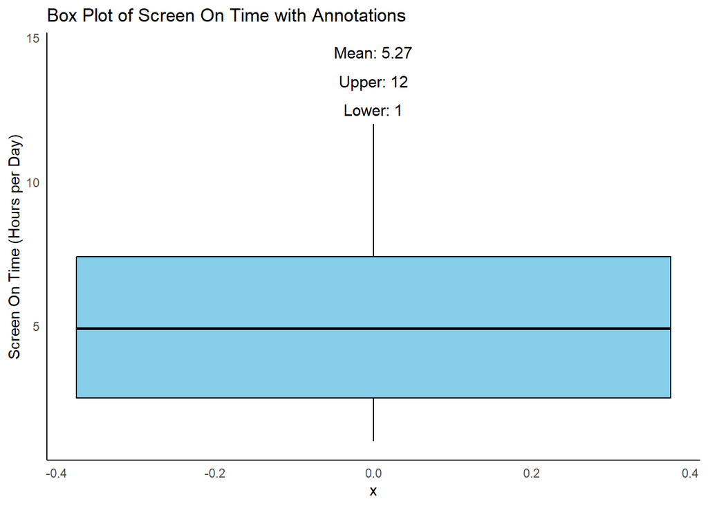

```r
# Calculate summary statistics for Screen On Time
box_summary <- data.frame(
  Metric = c("Mean", "Upper", "Lower"),
  Value = c(mean(data$Screen_Time_Hours_Per_Day, na.rm = TRUE),
            max(data$Screen_Time_Hours_Per_Day, na.rm = TRUE),
            min(data$Screen_Time_Hours_Per_Day, na.rm = TRUE)),
  y = c(14.5, 13.5, 12.5)
)

# Add a constant x value since this is a single variable plot
box_summary$x <- 1

# Create the box plot with annotated text
ggplot(data, aes(y = Screen_Time_Hours_Per_Day)) +
  geom_boxplot(fill = "skyblue", color = "black", outlier.color = "red", outlier.shape = 16) +
  geom_text(data = box_summary, aes(x = 0, y = y, label = paste0(Metric, ": ", round(Value, 2))),
            inherit.aes = FALSE, size = 4, color = "black") +
  theme_minimal() +
  theme(
    panel.grid = element_blank(),
    axis.line = element_line(color = "black")
  ) +
  labs(
    title = "Box Plot of Screen On Time with Annotations",
    y = "Screen On Time (Hours per Day)"
  )
```

#### Gender

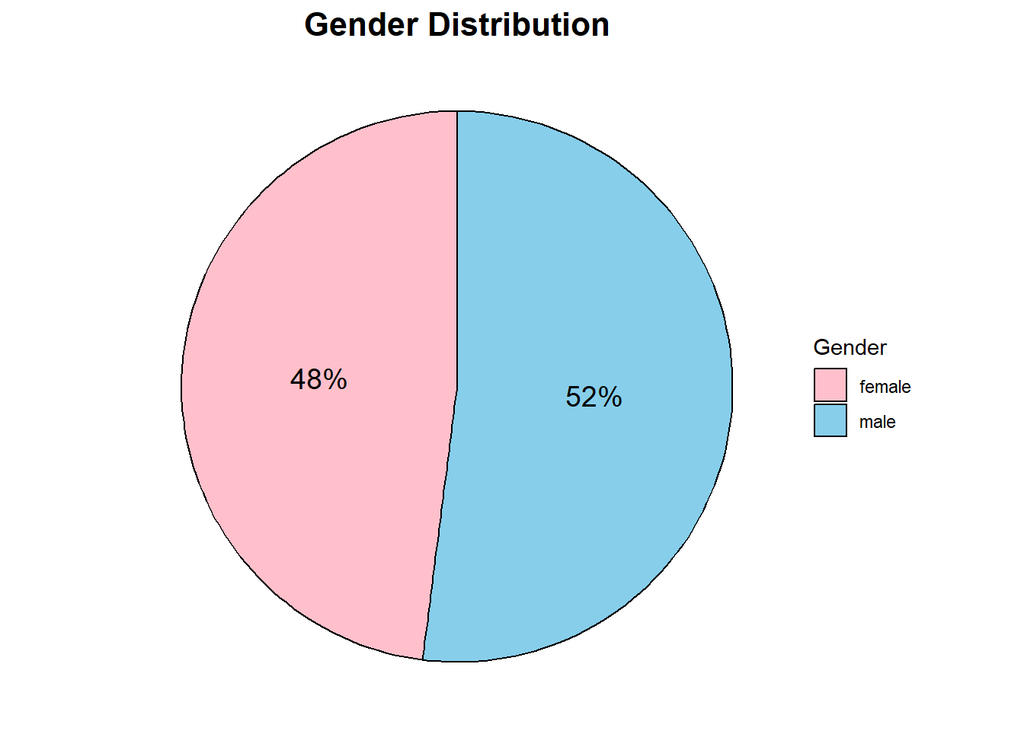

```r
gender_counts <- as.data.frame(table(data$Gender))
colnames(gender_counts) <- c("Gender", "Count")

# Calculate percentages
gender_counts$Percentage <- round((gender_counts$Count / sum(gender_counts$Count)) * 100, 1)

# Create the polar graph with percentage labels
ggplot(gender_counts, aes(x = "", y = Count, fill = Gender)) +
  geom_bar(stat = "identity", width = 1, color = "black") +
  coord_polar(theta = "y") +
  scale_fill_manual(values = c("male" = "skyblue", "female" = "pink")) +
  geom_text(aes(label = paste0(Percentage, "%")),
            position = position_stack(vjust = 0.5), color ="black", size = 5) +
  labs(
    title = "Gender Distribution",
    fill = "Gender"
  ) +
  theme_void() +
  theme(
    plot.title = element_text(size = 16, face = "bold", hjust = 0.5)
  )
```

#### User Behaviour Class

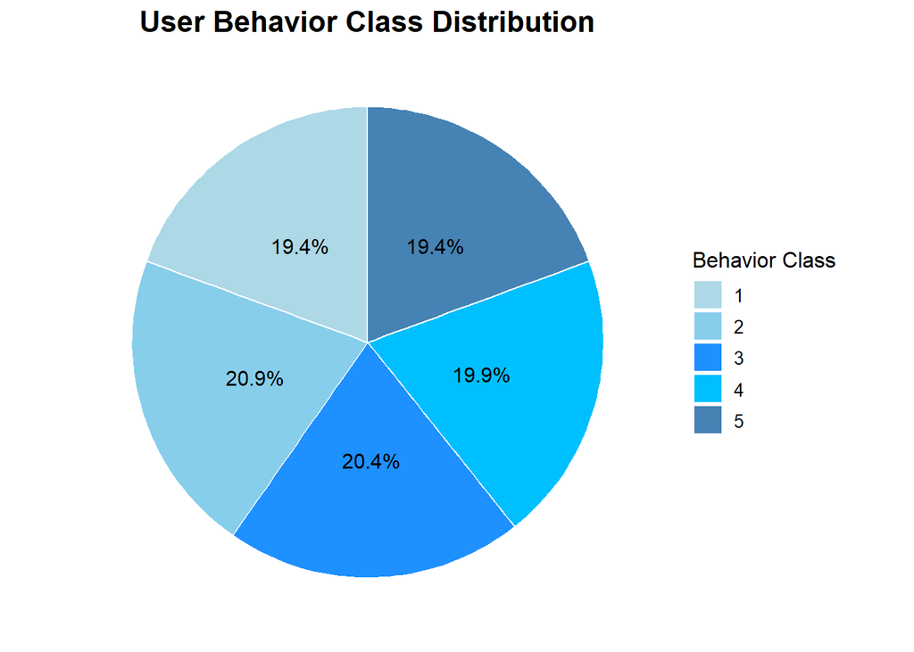

```r
user_class_distribution <- data %>%
  count(User_Behavior_Class) %>%
  mutate(Percentage = round(n / sum(n) * 100, 1))

# Create a pie chart
ggplot(user_class_distribution, aes(x = "", y = Percentage, fill = as.factor(User_Behavior_Class))) +
  geom_bar(stat = "identity", width = 1, color = "white") +
  coord_polar(theta = "y") +
  labs(
    title = "User Behavior Class Distribution",
    fill = "Behavior Class"
  ) +
  geom_text(aes(label = paste0(Percentage, "%")),
            position = position_stack(vjust = 0.5), size = 4, color = "black") +
  scale_fill_manual(values = c("lightblue", "skyblue", "dodgerblue", "deepskyblue", "steelblue")) +
  theme_minimal() +
  theme(
    plot.title = element_text(size = 16, face = "bold", hjust = 0.5),
    axis.title = element_blank(),
    axis.text = element_blank(),
    panel.grid = element_blank(),
    legend.title = element_text(size = 12),
    legend.text = element_text(size = 10)
  )
```

#### User Behaviour Class by App Usage and Gender (Volin Plot)

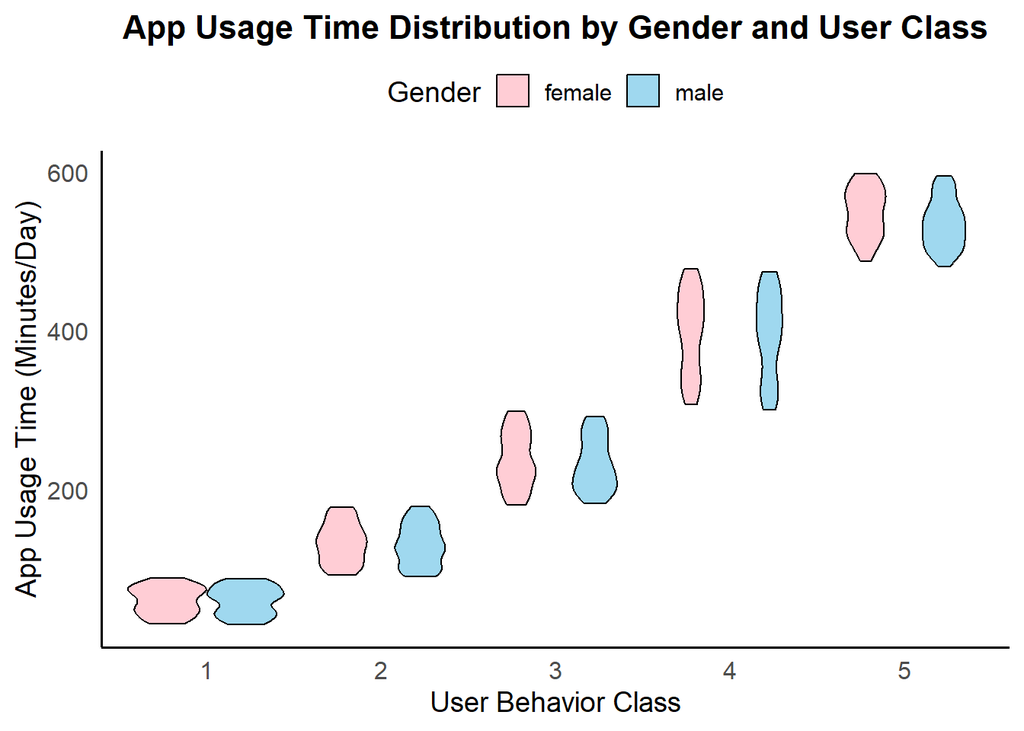

```r
# Violin Plot for App Usage Time Distribution by Gender and User Class
ggplot(data, aes(x = as.factor(User_Behavior_Class), y = App_Usage_Time_Mins_Per_Day, fill = Gender)) +
  geom_violin(alpha = 0.8, color = "black") +
  labs(
    title = "App Usage Time Distribution by Gender and User Class",
    x = "User Behavior Class",
    y = "App Usage Time (Minutes/Day)",
    fill = "Gender"
  ) +
  scale_fill_manual(values = c("male" = "skyblue", "female" = "pink")) +
  theme_minimal(base_size = 14) +
  theme(
    plot.title = element_text(size = 16, face = "bold", hjust = 0.5),
    axis.text = element_text(size = 12),
    axis.title = element_text(size = 14),
    legend.position = "top",
    panel.grid = element_blank(),
    axis.line = element_line(color = "black")
  )
```

#### Same using Box plot for seeing actual difference between Gender

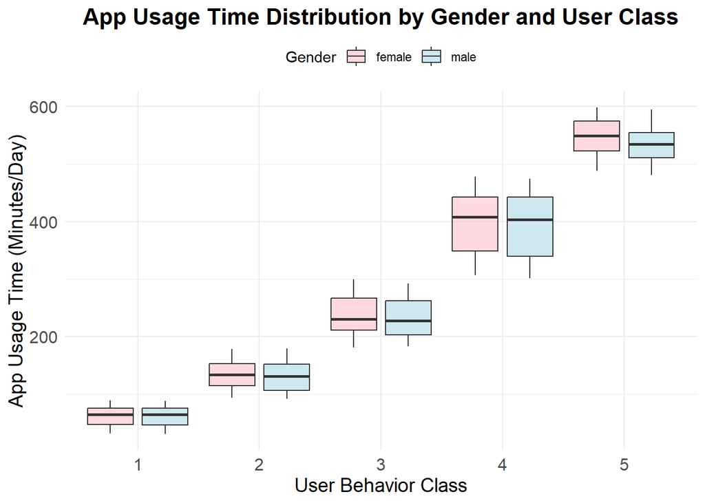

```r
# Box Plot
ggplot(data, aes(x = as.factor(User_Behavior_Class), y = App_Usage_Time_Mins_Per_Day, fill = Gender)) +
  geom_boxplot(alpha = 0.6, position = position_dodge(0.9), outlier.shape = NA) +
  labs(
    title = "App Usage Time Distribution by Gender and User Class",
    x = "User Behavior Class",
    y = "App Usage Time (Minutes/Day)",
    fill = "Gender",
    color = "Gender"
  ) +
  theme_minimal() +
  theme(
    plot.title = element_text(size = 16, face = "bold", hjust = 0.5),
    axis.text = element_text(size = 12),
    axis.title = element_text(size = 14),
    legend.position = "top"
  ) +
  scale_fill_manual(values = c("pink", "lightblue"))
```

#### Bar Graph for the Average App Usage Time by Gender and User Behavior Class

```r
bar_data <- data %>%
  group_by(User_Behavior_Class, Gender) %>%
  summarise(Average_App_Usage = mean(App_Usage_Time_Mins_Per_Day, na.rm = TRUE)) %>%
  ungroup()
```

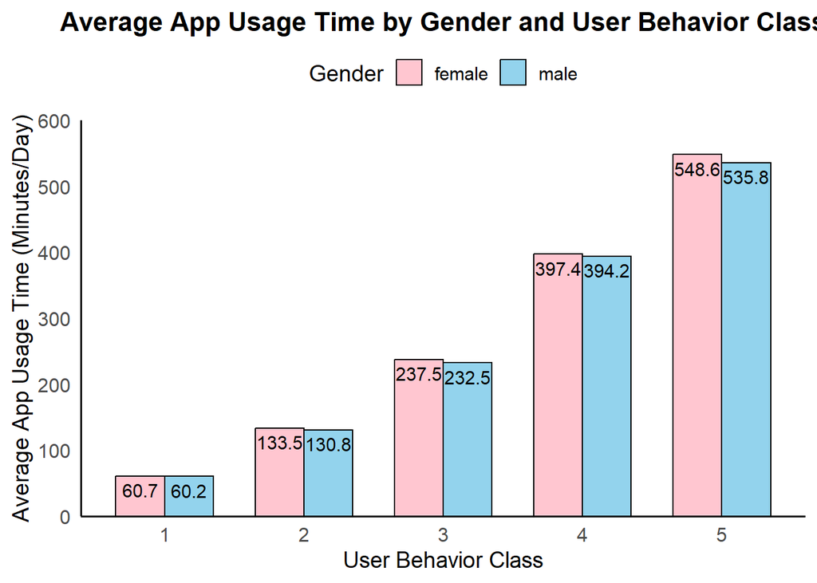

```r
ggplot(bar_data, aes(x = as.factor(User_Behavior_Class), y = Average_App_Usage, fill = Gender)) +
  geom_bar(stat = "identity", position = "dodge", color = "black", alpha = 0.9, width = 0.7) +
  geom_text(aes(label = round(Average_App_Usage, 1)),
            position = position_dodge(0.7), vjust = 1.5, hjust= 0.5, size = 4, color = "black") +
  labs(
    title = "Average App Usage Time by Gender and User Behavior Class",
    x = "User Behavior Class",
    y = "Average App Usage Time (Minutes/Day)",
    fill = "Gender"
  ) +
  scale_fill_manual(values = c("male" = "skyblue", "female" = "pink")) +
  scale_y_continuous(expand = c(0, 0), limits = c(0, 600)) +
  theme_minimal(base_size = 14) +
  theme(
    plot.title = element_text(size = 16, face = "bold", hjust = 0.5),
    axis.text = element_text(size = 12),
    axis.title = element_text(size = 14),
    legend.position = "top",
    panel.grid = element_blank(),
    axis.line = element_line(color = "black")
  )
```

#### Average Data Usage by User Behaviour Class

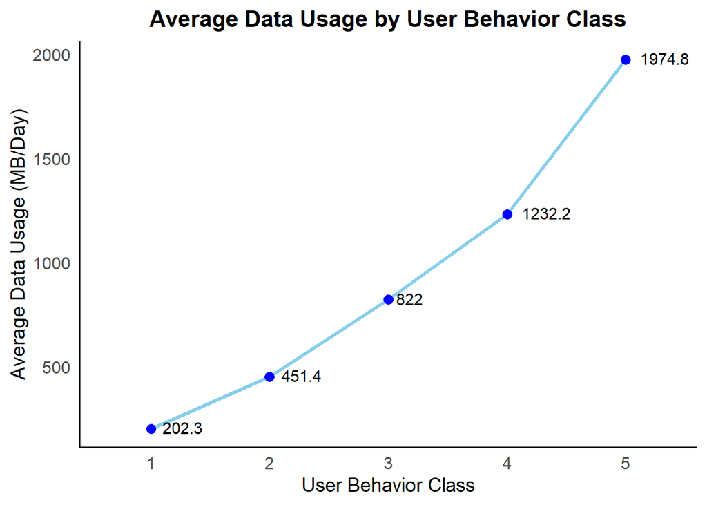

```r
avg_data_usage <- data %>%
  group_by(User_Behavior_Class) %>%
  summarise(Average_Data_Usage = round(mean(Data_Usage_MB_Per_Day, na.rm = TRUE), 1))

# Line plot
ggplot(avg_data_usage, aes(x = as.factor(User_Behavior_Class), y = Average_Data_Usage, group = 1)) +
  geom_line(color = "skyblue", size = 1.2) +
  geom_point(color = "blue", size = 3) +
  geom_text(aes(label = Average_Data_Usage), vjust = 0.4, hjust = -0.3, size = 4) +
  labs(
    title = "Average Data Usage by User Behavior Class",
    x = "User Behavior Class",
    y = "Average Data Usage (MB/Day)"
  ) +
  theme_minimal(base_size = 14) +
  theme(
    plot.title = element_text(size = 16, face = "bold", hjust = 0.5),
    axis.text = element_text(size = 12),
    axis.title = element_text(size = 14),
    panel.grid = element_blank(),
    axis.line = element_line(color = "black")
  )
```

#### Average Number of Apps Installed by User Behaviour Class and Gender

```r
# Summarize the data for the average number of apps installed by User Behavior Class and Gender
avg_apps_installed_gender <- data %>%
  group_by(User_Behavior_Class, Gender) %>%
  summarise(Average_Apps_Installed = round(mean(Number_Of_Apps_Installed, na.rm = TRUE), 0)) %>%
  mutate(User_Behavior_Class = as.factor(User_Behavior_Class))
```

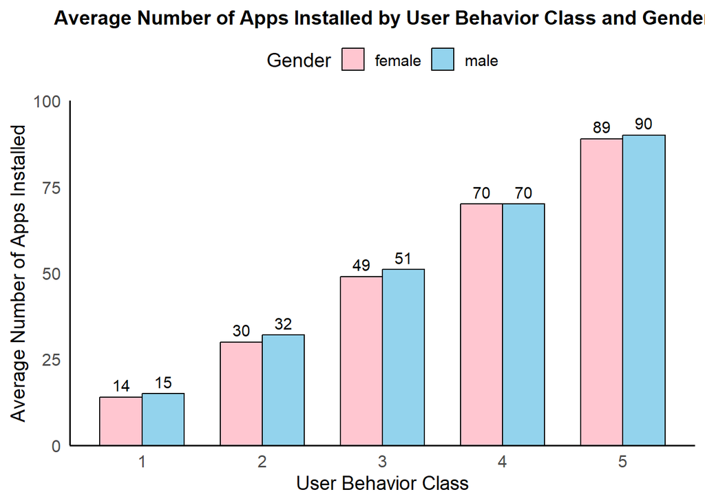

```r
# Plot the average number of apps installed by User Behavior Class and Gender
ggplot(avg_apps_installed_gender, aes(x = User_Behavior_Class, y = Average_Apps_Installed, fill = Gender)) +
  geom_bar(stat = "identity", position = "dodge", color = "black", alpha = 0.9, width = 0.7) +
  geom_text(aes(label = Average_Apps_Installed), position = position_dodge(width = 0.7), vjust = -0.5, size = 4, color = "black") +
  scale_fill_manual(values = c("female" = "pink", "male" = "skyblue")) +
  labs(
    title = "Average Number of Apps Installed by User Behavior Class and Gender",
    x = "User Behavior Class",
    y = "Average Number of Apps Installed",
    fill = "Gender"
  ) +
  scale_y_continuous(expand = c(0, 0), limits = c(0, 100)) +
  theme_minimal(base_size = 14) +
  theme(
    plot.title = element_text(size = 14, face = "bold", hjust = 0.5),
    axis.text = element_text(size = 12),
    axis.title = element_text(size = 14),
    panel.grid = element_blank(),
    axis.line = element_line(color = "black"),
    legend.position = "top"
  )
```

#### Screen Time by User Behaviour Class

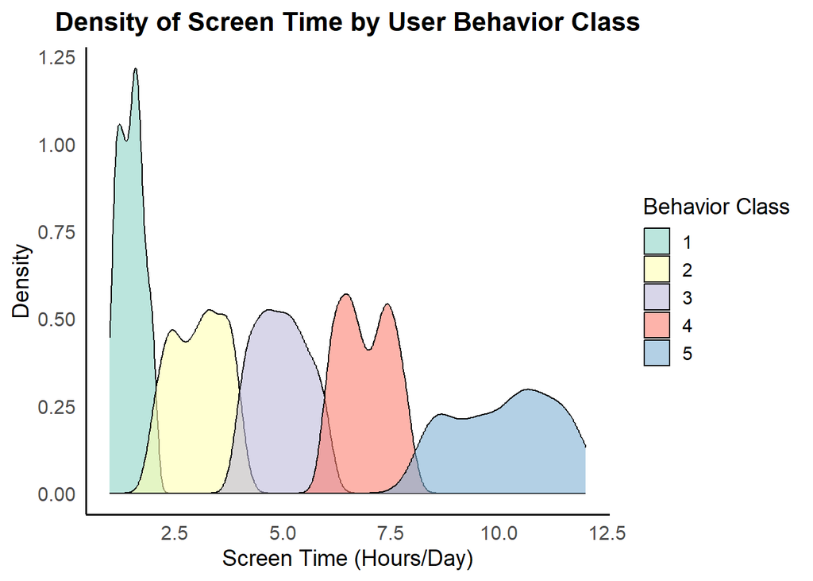

```r
ggplot(data, aes(x = Screen_Time_Hours_Per_Day, fill = as.factor(User_Behavior_Class))) +
  geom_density(alpha = 0.6) +
  scale_fill_brewer(palette = "Set3") +
  labs(
    title = "Density of Screen Time by User Behavior Class",
    x = "Screen Time (Hours/Day)",
    y = "Density",
    fill = "Behavior Class"
  ) +
  theme_minimal(base_size = 14) +
  theme(
    plot.title = element_text(size = 16, face = "bold", hjust = 0.5),
    axis.text = element_text(size = 12),
    axis.title = element_text(size = 14),
    legend.position = "right",
    panel.grid = element_blank(),
    axis.line = element_line(color = "black")
  )
```

#### Average Data Usage by User Behaviour Class and Age Group

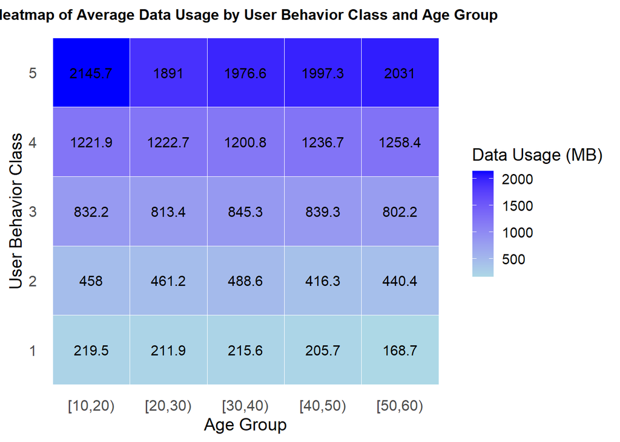

```r
heatmap_data <- data %>%
  group_by(User_Behavior_Class, Age_Group) %>%
  summarise(Average_Data_Usage = round(mean(Data_Usage_MB_Per_Day, na.rm = TRUE), 1))
# Heatmap
ggplot(heatmap_data, aes(x = Age_Group, y = as.factor(User_Behavior_Class), fill = Average_Data_Usage)) +
  geom_tile(color = "white") +
  geom_text(aes(label = Average_Data_Usage), size = 4, color = "black") +
  scale_fill_gradient(low = "lightblue", high = "blue", name = "Data Usage (MB)") +
  labs(
    title = "Heatmap of Average Data Usage by User Behavior Class and Age Group",
    x = "Age Group",
    y = "User Behavior Class"
  ) +
  theme_minimal(base_size = 14) +
  theme(
    plot.title = element_text(size = 12, face = "bold", hjust = 0.5),
    axis.text = element_text(size = 12),
    axis.title = element_text(size = 14),
    panel.grid = element_blank()
  )
```

#### User Behaviour Class relationship with all Variaables

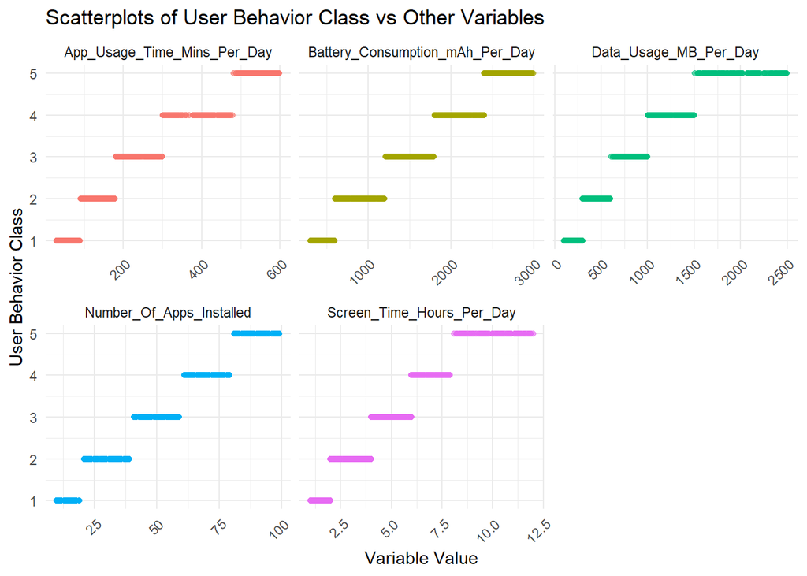

```r
# Select relevant variables
scatter_data <- data[, c("User_Behavior_Class",
                         "Screen_Time_Hours_Per_Day",
                         "Battery_Consumption_mAh_Per_Day",
                         "Data_Usage_MB_Per_Day",
                         "App_Usage_Time_Mins_Per_Day",
                         "Number_Of_Apps_Installed")]

# Convert data to long format for faceting
scatter_long <- pivot_longer(scatter_data,
                             cols = -User_Behavior_Class,
                             names_to = "Variable",
                             values_to = "Value")

# Plot scatterplots with faceting
ggplot(scatter_long, aes(x = Value, y = User_Behavior_Class, color = Variable)) +
  geom_point(alpha = 0.6) +
  facet_wrap(~ Variable, scales = "free_x") +
  labs(title = "Scatterplots of User Behavior Class vs Other Variables",
       x = "Variable Value",
       y = "User Behavior Class") +
  theme_minimal() +
  theme(legend.position = "none",
        axis.text.x = element_text(angle = 45, vjust = 1, hjust = 1))
```

#### Battery Usage vs Data Usage by User Behaviour Class and Gender

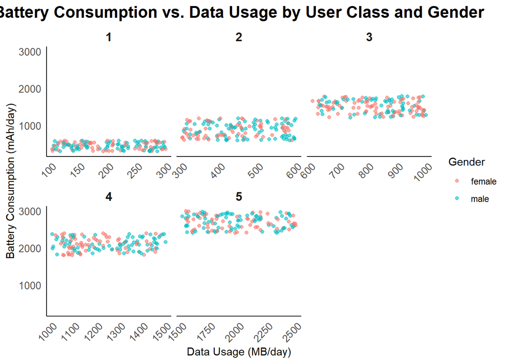

```r
ggplot(data, aes(x = Data_Usage_MB_Per_Day, y = Battery_Consumption_mAh_Per_Day, color = Gender)) +
  geom_point(alpha = 0.6) +
  facet_wrap(~ User_Behavior_Class,scales = "free_x") +
  labs(title = "Battery Consumption vs. Data Usage by User Class and Gender",
       x = "Data Usage (MB/day)",
       y = "Battery Consumption (mAh/day)",
       color = "Gender") +
  theme_minimal() +
    theme(
    plot.title = element_text(size = 16, face = "bold", hjust = 0.5),
    strip.text = element_text(size = 12, face = "bold"),
    axis.line = element_line(color = "black"),
    panel.grid = element_blank(),
    axis.text.x = element_text(angle = 45, vjust = 1, hjust = 1, size = 10),
    axis.text.y = element_text(size = 10),
    legend.position = "right"
  )
```

#### Initial Graphs :Created by Me. But is not used as such in the report or PPT

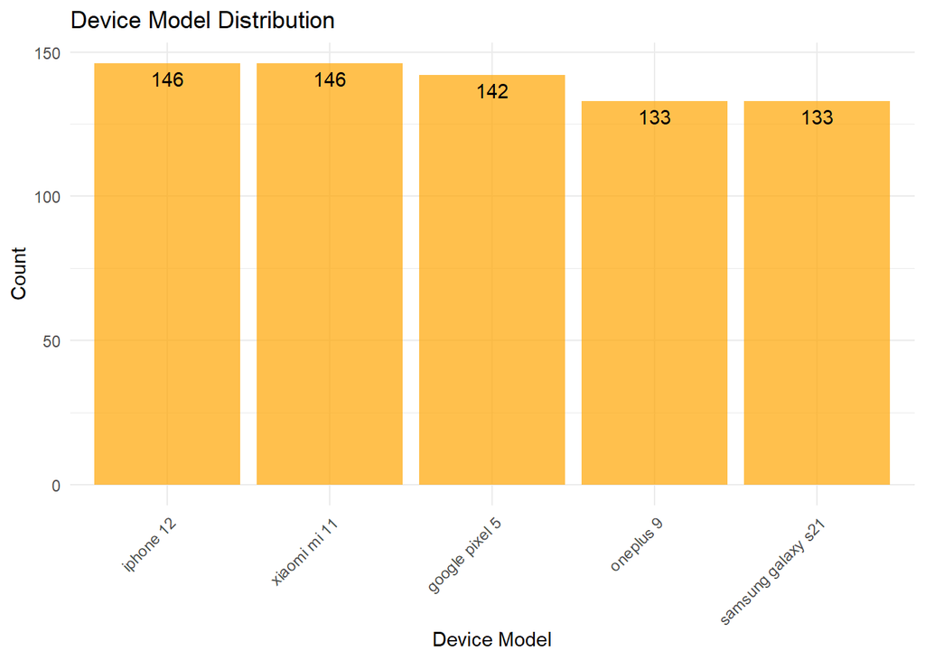

```r
# Bar Plot of Device Models
ggplot(data, aes(x = reorder(Device_Model, Device_Model, function(x) -length(x)))) +
  geom_bar(fill = "orange", alpha = 0.7) +
  geom_text(stat = "count", aes(label = ..count..), vjust = 1.5, color = "black") +
  labs(title = "Device Model Distribution", x = "Device Model", y = "Count") +
  theme_minimal() +
  theme(axis.text.x = element_text(angle = 45, hjust = 1))
```

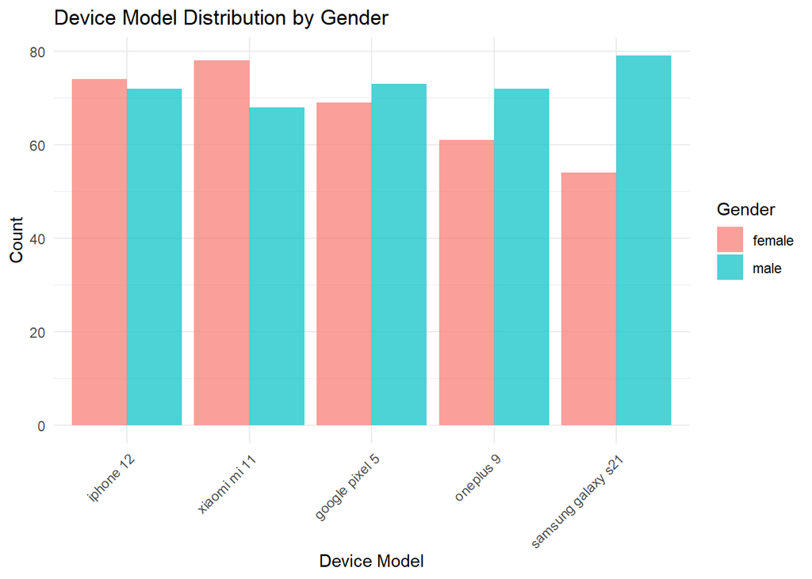

```r
ggplot(data, aes(x = reorder(Device_Model, Device_Model, function(x) -length(x)), fill = Gender)) +
  geom_bar(position = "dodge", alpha = 0.7) +
  labs(title = "Device Model Distribution by Gender", x = "Device Model", y = "Count") +
  theme_minimal() +
  theme(axis.text.x = element_text(angle = 45, hjust = 1))
```

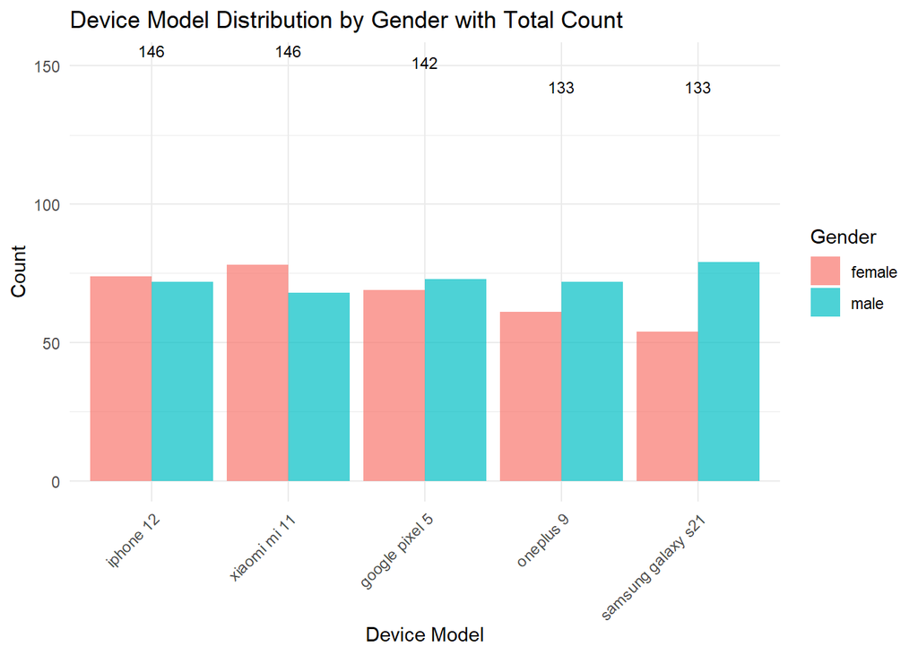

```r
# Load necessary libraries
library(dplyr)
library(ggplot2)

# Calculate total count per device model
total_counts <- data %>%
  group_by(Device_Model) %>%
  summarise(Total = n())

# Create the grouped bar chart with total count labels
ggplot(data, aes(x = reorder(Device_Model, -table(Device_Model)[Device_Model]), fill = Gender)) +
  geom_bar(position = "dodge", alpha = 0.7) +
  geom_text(data = total_counts, aes(x = Device_Model, y = Total + 5, label = Total),
            inherit.aes = FALSE, color = "black", size = 3, vjust = -0.5) +
  labs(title = "Device Model Distribution by Gender with Total Count",
       x = "Device Model", y = "Count") +
  theme_minimal() +
  theme(axis.text.x = element_text(angle = 45, hjust = 1))
```

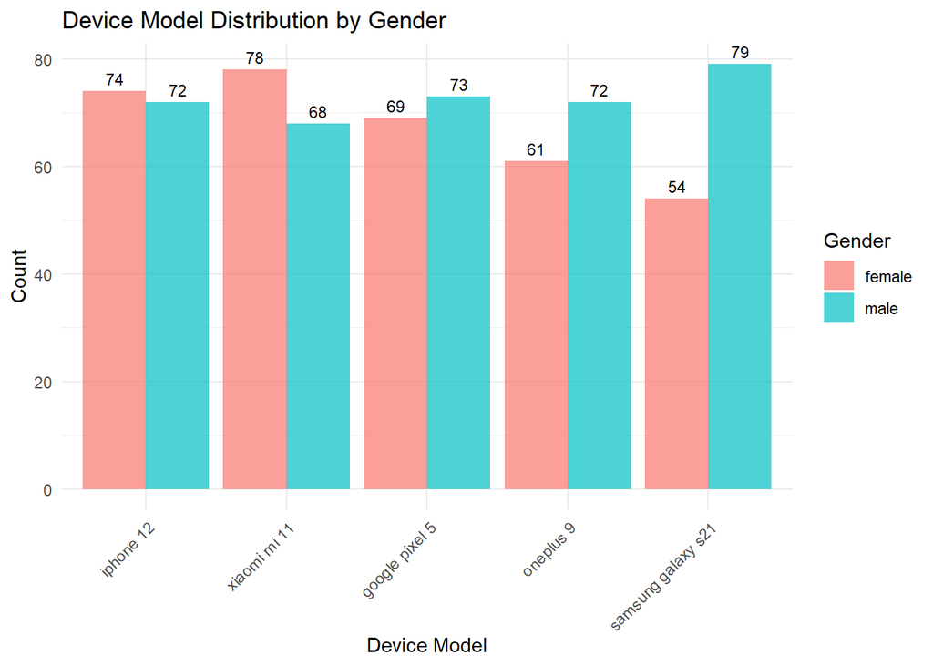

```r
ggplot(data, aes(x = reorder(Device_Model, -table(Device_Model)[Device_Model]), fill = Gender)) +
  geom_bar(position = "dodge", alpha = 0.7) +
  geom_text(stat = "count", aes(label = ..count..),
            position = position_dodge(width = 0.9), vjust = -0.5, color = "black", size = 3) +
  labs(title = "Device Model Distribution by Gender",
       x = "Device Model", y = "Count") +
  theme_minimal() +
  theme(axis.text.x = element_text(angle = 45, hjust = 1))
```

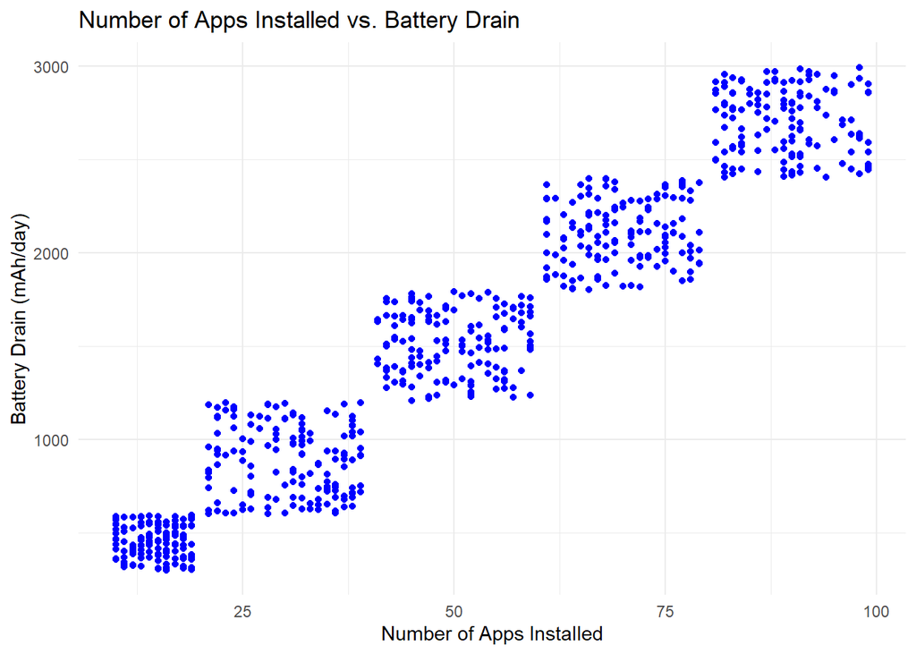

```r
# Scatter plot for Number of Apps Installed vs. Battery Drain
ggplot(data, aes(x = Number_Of_Apps_Installed, y = Battery_Consumption_mAh_Per_Day)) +
  geom_point(color = "blue") +
  labs(
    title = "Number of Apps Installed vs. Battery Drain",
    x = "Number of Apps Installed",
    y = "Battery Drain (mAh/day)"
  ) +
  theme_minimal()
```

# Homework 7

#Visulaising User Behavior class using bar and pie chart

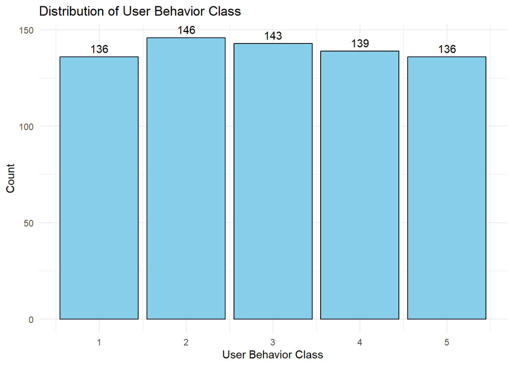

```r
# Bar Plot for User_Behavior_Class
ggplot(data, aes(x = User_Behavior_Class)) +
  geom_bar(fill = "skyblue", color = "black") +
  geom_text(stat = "count", aes(label = ..count..), vjust = -0.5) +
  labs(
    title = "Distribution of User Behavior Class",
    x = "User Behavior Class",
    y = "Count"
  ) +
  theme_minimal()
```

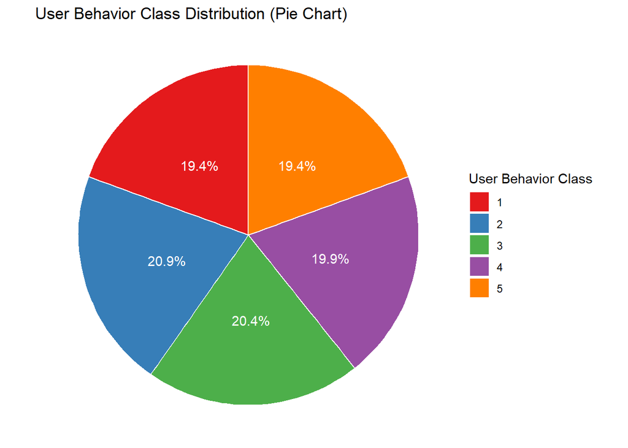

```r
# Pie Chart for User_Behavior_Class
behavior_counts <- data %>%
  dplyr::count(User_Behavior_Class) %>%
  dplyr::mutate(percentage = n / sum(n) * 100)

ggplot(behavior_counts, aes(x = "", y = percentage, fill = as.factor(User_Behavior_Class))) +
  geom_col(width = 1, color = "white") +
  coord_polar(theta = "y") +
  geom_text(aes(label = paste0(round(percentage, 1), "%")),
            position = position_stack(vjust = 0.5), color = "white") +
  scale_fill_brewer(palette = "Set1") +
  labs(
    title = "User Behavior Class Distribution (Pie Chart)",
    x = NULL,
    y = NULL,
    fill = "User Behavior Class"
  ) +
  theme_void() +
  theme(legend.position = "right")
```

#Visualising Screen_Time_Hours_Per_Day

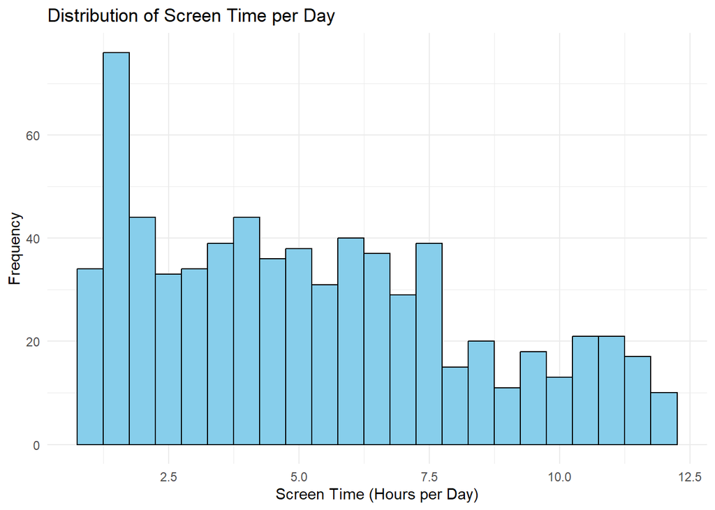

```r
ggplot(data, aes(x = Screen_Time_Hours_Per_Day)) +
  geom_histogram(binwidth = 0.5, fill = "skyblue", color = "black") +
  labs(
    title = "Distribution of Screen Time per Day",
    x = "Screen Time (Hours per Day)",
    y = "Frequency"
  ) +
  theme_minimal()
```

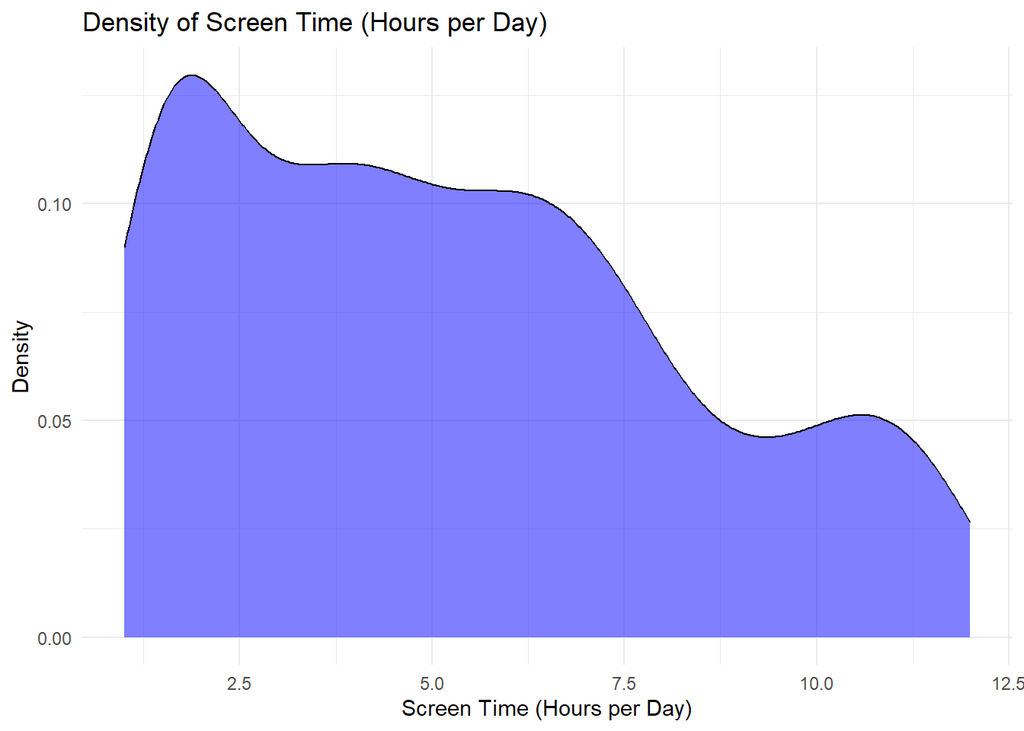

```r
ggplot(data, aes(x = Screen_Time_Hours_Per_Day)) +
  geom_density(fill = "blue", alpha = 0.5) +
  labs(
    title = "Density of Screen Time (Hours per Day)",
    x = "Screen Time (Hours per Day)",
    y = "Density"
  ) +
  theme_minimal()
```

#Visualising Gender

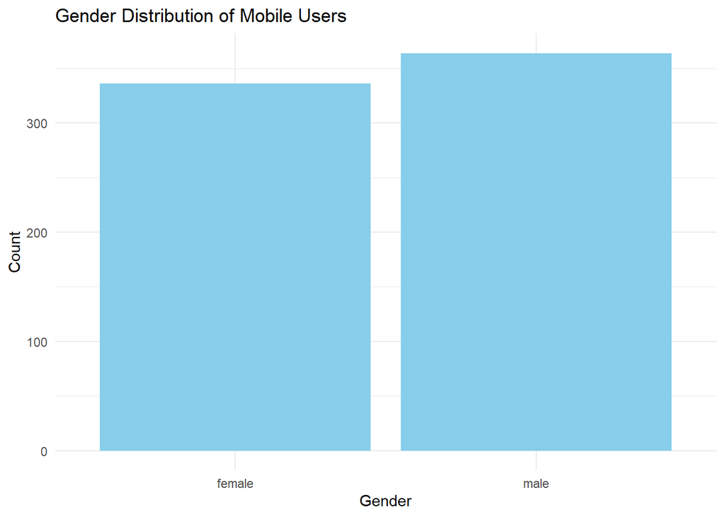

```r
ggplot(data, aes(x = Gender)) +
  geom_bar(fill = "skyblue") +
  labs(title = "Gender Distribution of Mobile Users", x = "Gender", y = "Count") +
  theme_minimal()
```

#Visualising Age

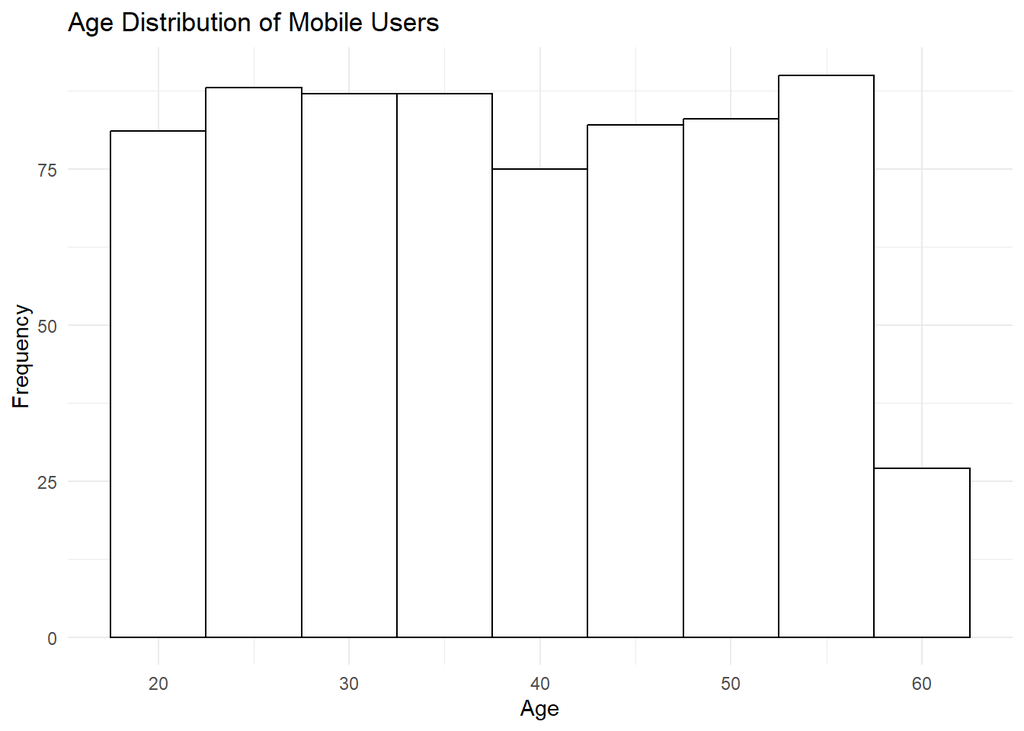

```r
 #2. Age Distribution - Histogram
ggplot(data, aes(x = Age)) +
  geom_histogram(binwidth = 5, fill = "white", color = "black") +
  labs(title = "Age Distribution of Mobile Users", x = "Age", y = "Frequency") +
  theme_minimal()
```

#Visualising Battery Drain

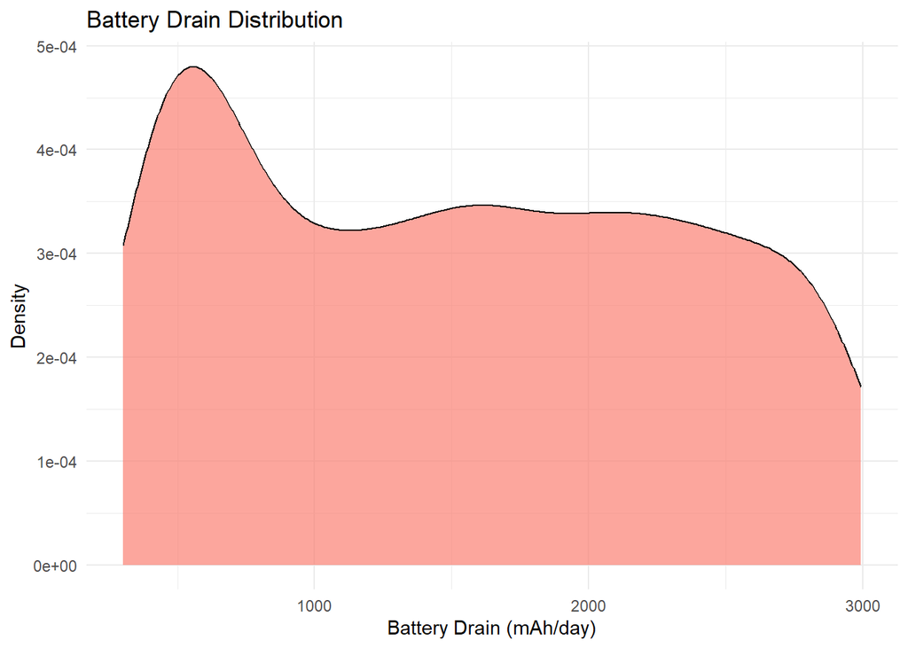

```r
# 3. Battery Drain (mAh/day) - Density Plot
ggplot(data, aes(x = `Battery_Consumption_mAh_Per_Day`)) +
  geom_density(fill = "salmon", alpha = 0.7) +
  labs(title = "Battery Drain Distribution", x = "Battery Drain (mAh/day)", y = "Density") +
  theme_minimal()
```

#Visualising Device Model

```r
# Get unique values of Device.Model
unique_models <- unique(data$Device_Model)
print(unique_models)
```

```
## [1] "google pixel 5"     "oneplus 9"          "xiaomi mi 11"
## [4] "iphone 12"          "samsung galaxy s21"
```

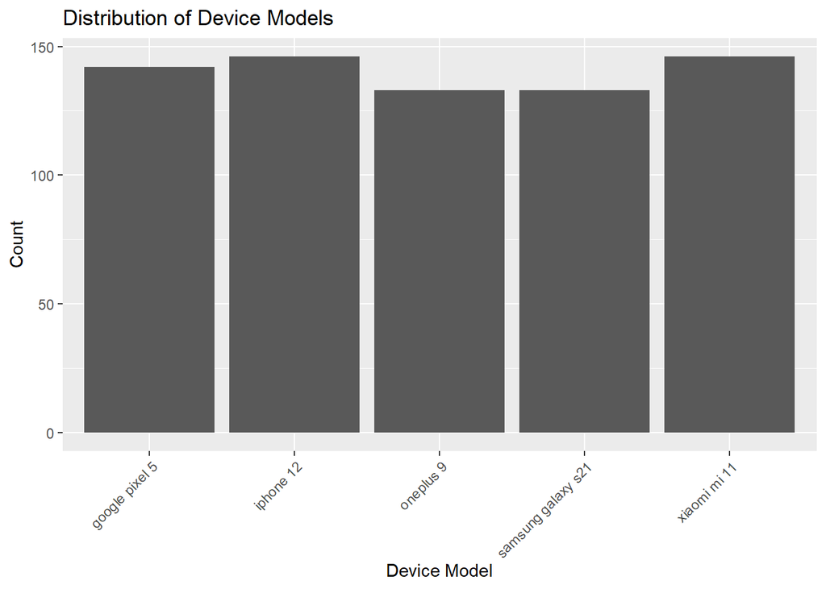

```r
# Bar chart for Device Model

ggplot(data, aes(x = Device_Model)) +
  geom_bar() +
  theme(axis.text.x = element_text(angle = 45, hjust = 1)) +
  labs(title = "Distribution of Device Models", x = "Device Model", y = "Count")
```

#Visualising Operating System

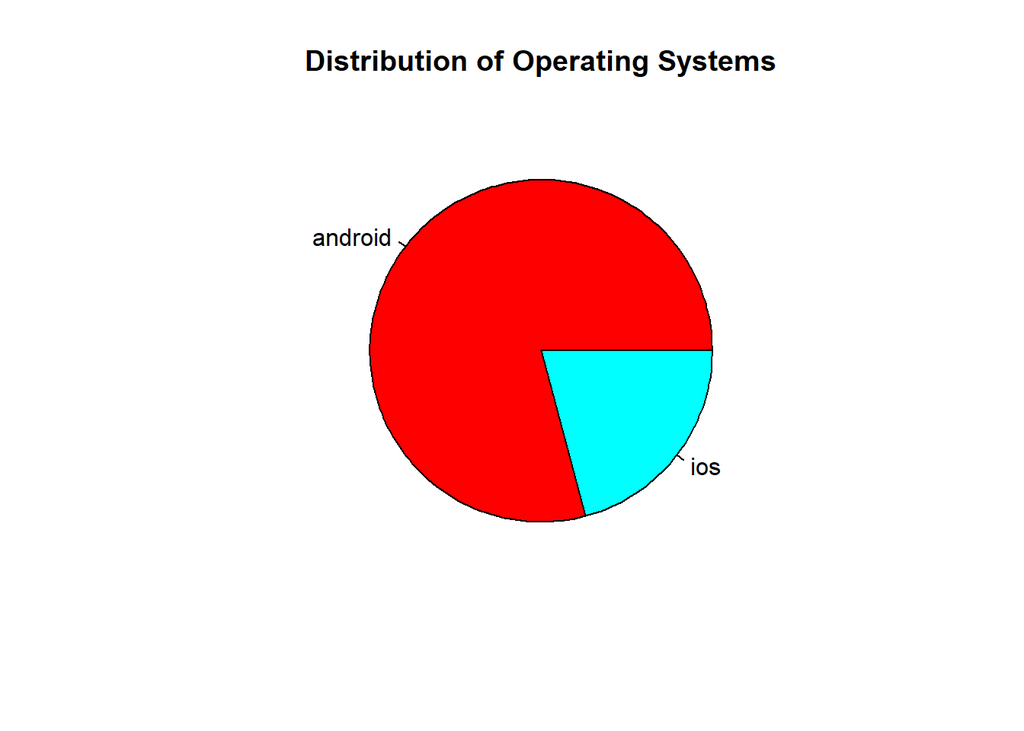

```r
# Pie chart for Operating System
os_counts <- table(data$Operating_System)
pie(os_counts, main = "Distribution of Operating Systems", col = rainbow(length(os_counts)))
```

#Visualising App_Usage_Time_Mins_Per_Day

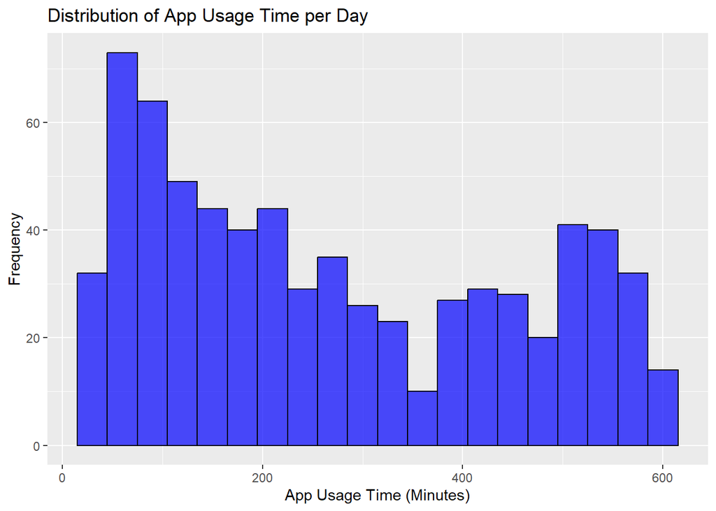

```r
# Histogram for App Usage Time
ggplot(data, aes(x = App_Usage_Time_Mins_Per_Day)) +
  geom_histogram(binwidth = 30, color = "black", fill = "blue", alpha = 0.7) +
  labs(title = "Distribution of App Usage Time per Day", x = "App Usage Time (Minutes)", y = "Frequency")
```

#Combination of Screen Time and User Class

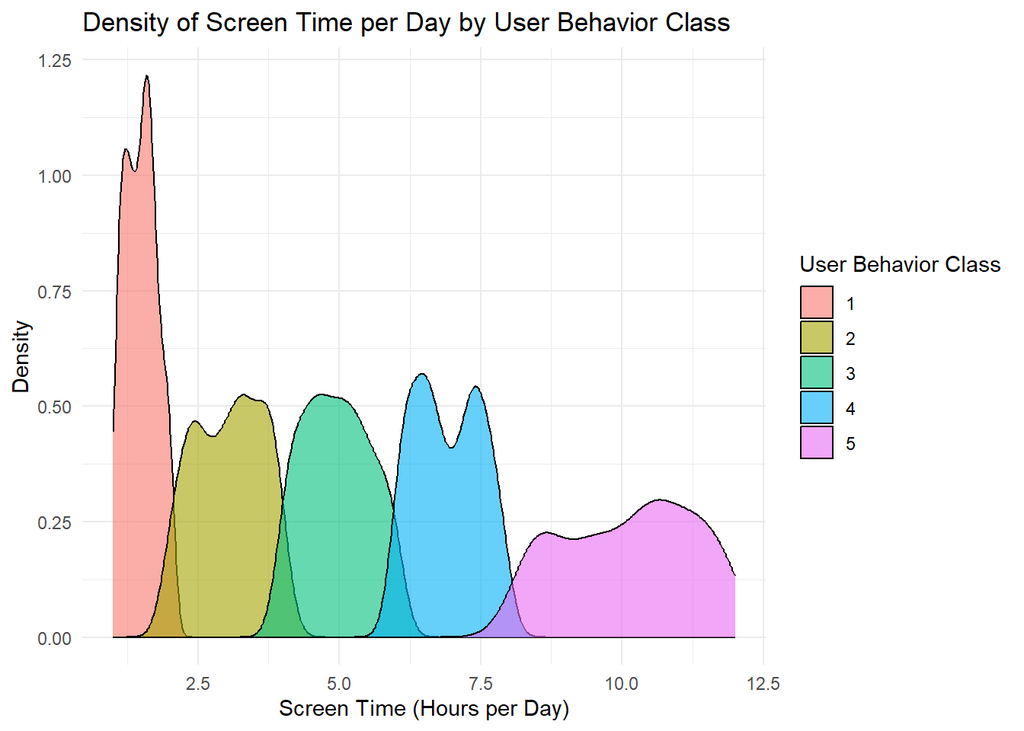

```r
ggplot(data, aes(x = Screen_Time_Hours_Per_Day, fill = as.factor(User_Behavior_Class))) +
  geom_density(alpha = 0.6) +
  labs(
    title = "Density of Screen Time per Day by User Behavior Class",
    x = "Screen Time (Hours per Day)",
    y = "Density",
    fill = "User Behavior Class"
  ) +
  theme_minimal()
```